# 5123 Final Prpject

2026-04-09

EPSY5123 Jianjian’s Project

### Research Question

The main research question of this project is: To what extent are family-related factors associated with students’ Portuguese language performance?

### Data Source

The dataset I used is the public Portuguese language dataset in UCI Student Performance repository, which included the student records from two Portuguese secondary schools. The dataset contains students’ Portuguese language grades and background information. The full dataset includes 649 cases, 30 predictor features regarding demographic, family, social, and school-related variables and Portuguese language score records.

#*original data source: https://archive.ics.uci.edu/dataset/320/student+performance (click the link and you can find the dataset introduction information)

### Database preparation

##Loading the packages and checking the original data.

```r
# loading packages
library(ggplot2)
library(tidyverse)
library(dplyr)

# loading and checking data
student.por_cleaned <- read.csv("student-por_cleaned.csv")
head(student.por_cleaned)
```

```
##   school sex age address famsize Pstatus Medu Fedu     Mjob     Fjob     reason
## 1     GP   F  18       U     GT3       A    4    4  at_home  teacher     course
## 2     GP   F  17       U     GT3       T    1    1  at_home    other     course
## 3     GP   F  15       U     LE3       T    1    1  at_home    other      other
## 4     GP   F  15       U     GT3       T    4    2   health services       home
## 5     GP   F  16       U     GT3       T    3    3    other    other       home
## 6     GP   M  16       U     LE3       T    4    3 services    other reputation
##   guardian traveltime studytime failures schoolsup famsup paid activities
## 1   mother          2         2        0       yes     no   no         no
## 2   father          1         2        0        no    yes   no         no
## 3   mother          1         2        0       yes     no   no         no
## 4   mother          1         3        0        no    yes   no        yes
## 5   father          1         2        0        no    yes   no         no
## 6   mother          1         2        0        no    yes   no        yes
##   nursery higher internet romantic famrel freetime goout Dalc Walc health
## 1     yes    yes       no       no      4        3     4    1    1      3
## 2      no    yes      yes       no      5        3     3    1    1      3
## 3     yes    yes      yes       no      4        3     2    2    3      3
## 4     yes    yes      yes      yes      3        2     2    1    1      5
## 5     yes    yes       no       no      4        3     2    1    2      5
## 6     yes    yes      yes       no      5        4     2    1    2      5
##   absences G1 G2 G3
## 1        4  0 11 11
## 2        2  9 11 11
## 3        6 12 13 12
## 4        0 14 14 14
## 5        0 11 13 13
## 6        6 12 12 13
```

```r
glimpse(student.por_cleaned)
```

```
## Rows: 649
## Columns: 33
## $ school     <chr> "GP", "GP", "GP", "GP", "GP", "GP", "GP", "GP", "GP", "GP",…
## $ sex        <chr> "F", "F", "F", "F", "F", "M", "M", "F", "M", "M", "F", "F",…
## $ age        <int> 18, 17, 15, 15, 16, 16, 16, 17, 15, 15, 15, 15, 15, 15, 15,…
## $ address    <chr> "U", "U", "U", "U", "U", "U", "U", "U", "U", "U", "U", "U",…
## $ famsize    <chr> "GT3", "GT3", "LE3", "GT3", "GT3", "LE3", "LE3", "GT3", "LE…
## $ Pstatus    <chr> "A", "T", "T", "T", "T", "T", "T", "A", "A", "T", "T", "T",…
## $ Medu       <int> 4, 1, 1, 4, 3, 4, 2, 4, 3, 3, 4, 2, 4, 4, 2, 4, 4, 3, 3, 4,…
## $ Fedu       <int> 4, 1, 1, 2, 3, 3, 2, 4, 2, 4, 4, 1, 4, 3, 2, 4, 4, 3, 2, 3,…
## $ Mjob       <chr> "at_home", "at_home", "at_home", "health", "other", "servic…
## $ Fjob       <chr> "teacher", "other", "other", "services", "other", "other", …
## $ reason     <chr> "course", "course", "other", "home", "home", "reputation", …
## $ guardian   <chr> "mother", "father", "mother", "mother", "father", "mother",…
## $ traveltime <int> 2, 1, 1, 1, 1, 1, 1, 2, 1, 1, 1, 3, 1, 2, 1, 1, 1, 3, 1, 1,…
```

[output cut: 20 more lines]

##Revising the variable type of the dataset

So I need to correct the variable types.

After data revision, we know that in this dataset, there are 649 rows and 33 columns, which means we have 649 cases and 33 variables.

```r
# data backup
student <- student.por_cleaned
student
```

```
##     school sex age address famsize Pstatus Medu Fedu     Mjob     Fjob
## 1       GP   F  18       U     GT3       A    4    4  at_home  teacher
## 2       GP   F  17       U     GT3       T    1    1  at_home    other
## 3       GP   F  15       U     LE3       T    1    1  at_home    other
## 4       GP   F  15       U     GT3       T    4    2   health services
## 5       GP   F  16       U     GT3       T    3    3    other    other
## 6       GP   M  16       U     LE3       T    4    3 services    other
## 7       GP   M  16       U     LE3       T    2    2    other    other
## 8       GP   F  17       U     GT3       A    4    4    other  teacher
## 9       GP   M  15       U     LE3       A    3    2 services    other
## 10      GP   M  15       U     GT3       T    3    4    other    other
## 11      GP   F  15       U     GT3       T    4    4  teacher   health
## 12      GP   F  15       U     GT3       T    2    1 services    other
## 13      GP   M  15       U     LE3       T    4    4   health services
## 14      GP   M  15       U     GT3       T    4    3  teacher    other
```

[output cut: 2585 more lines]

```r
glimpse(student)
```

```
## Rows: 649
## Columns: 33
## $ school     <chr> "GP", "GP", "GP", "GP", "GP", "GP", "GP", "GP", "GP", "GP",…
## $ sex        <chr> "F", "F", "F", "F", "F", "M", "M", "F", "M", "M", "F", "F",…
## $ age        <int> 18, 17, 15, 15, 16, 16, 16, 17, 15, 15, 15, 15, 15, 15, 15,…
## $ address    <chr> "U", "U", "U", "U", "U", "U", "U", "U", "U", "U", "U", "U",…
## $ famsize    <chr> "GT3", "GT3", "LE3", "GT3", "GT3", "LE3", "LE3", "GT3", "LE…
## $ Pstatus    <chr> "A", "T", "T", "T", "T", "T", "T", "A", "A", "T", "T", "T",…
## $ Medu       <int> 4, 1, 1, 4, 3, 4, 2, 4, 3, 3, 4, 2, 4, 4, 2, 4, 4, 3, 3, 4,…
## $ Fedu       <int> 4, 1, 1, 2, 3, 3, 2, 4, 2, 4, 4, 1, 4, 3, 2, 4, 4, 3, 2, 3,…
## $ Mjob       <chr> "at_home", "at_home", "at_home", "health", "other", "servic…
## $ Fjob       <chr> "teacher", "other", "other", "services", "other", "other", …
## $ reason     <chr> "course", "course", "other", "home", "home", "reputation", …
## $ guardian   <chr> "mother", "father", "mother", "mother", "father", "mother",…
## $ traveltime <int> 2, 1, 1, 1, 1, 1, 1, 2, 1, 1, 1, 3, 1, 2, 1, 1, 1, 3, 1, 1,…
```

[output cut: 20 more lines]

```r
# changing variables from character into numeric ones
student$age <- as.numeric(student$age)
student$Medu <- as.numeric(student$Medu)
student$Fedu <- as.numeric(student$Fedu)
student$traveltime <- as.numeric(student$traveltime)
student$studytime <- as.numeric(student$studytime)
student$failures <- as.numeric(student$failures)
student$famrel <- as.numeric(student$famrel)
student$freetime <- as.numeric(student$freetime)
student$goout <- as.numeric(student$goout)
student$Dalc <- as.numeric(student$Dalc)
student$Walc <- as.numeric(student$Walc)
student$health <- as.numeric(student$health)
student$absences <- as.numeric(student$absences)
student$G1 <- as.numeric(student$G1)
student$G2 <- as.numeric(student$G2)
student$G3 <- as.numeric(student$G3)

# changing variables from character into factors
student$sex <- as.factor(student$sex)
student$address <- as.factor(student$address)
student$famsize <- as.factor(student$famsize)
student$Pstatus <- as.factor(student$Pstatus)
student$Mjob <- as.factor(student$Mjob)
student$Fjob <- as.factor(student$Fjob)
student$guardian <- as.factor(student$guardian)
student$schoolsup <- as.factor(student$schoolsup)
student$famsup <- as.factor(student$famsup)
student$paid <- as.factor(student$paid)
student$activities <- as.factor(student$activities)
student$nursery <- as.factor(student$nursery)
student$higher <- as.factor(student$higher)
student$internet <- as.factor(student$internet)
student$romantic <- as.factor(student$romantic)

# check the dataset: 649 rows and 33 columns
glimpse(student) # now we have done the data preparation for analysis
```

```
## Rows: 649
## Columns: 33
## $ school     <chr> "GP", "GP", "GP", "GP", "GP", "GP", "GP", "GP", "GP", "GP",…
## $ sex        <fct> F, F, F, F, F, M, M, F, M, M, F, F, M, M, M, F, F, F, M, M,…
## $ age        <dbl> 18, 17, 15, 15, 16, 16, 16, 17, 15, 15, 15, 15, 15, 15, 15,…
## $ address    <fct> U, U, U, U, U, U, U, U, U, U, U, U, U, U, U, U, U, U, U, U,…
## $ famsize    <fct> GT3, GT3, LE3, GT3, GT3, LE3, LE3, GT3, LE3, GT3, GT3, GT3,…
## $ Pstatus    <fct> A, T, T, T, T, T, T, A, A, T, T, T, T, T, A, T, T, T, T, T,…
## $ Medu       <dbl> 4, 1, 1, 4, 3, 4, 2, 4, 3, 3, 4, 2, 4, 4, 2, 4, 4, 3, 3, 4,…
## $ Fedu       <dbl> 4, 1, 1, 2, 3, 3, 2, 4, 2, 4, 4, 1, 4, 3, 2, 4, 4, 3, 2, 3,…
## $ Mjob       <fct> at_home, at_home, at_home, health, other, services, other, …
## $ Fjob       <fct> teacher, other, other, services, other, other, other, teach…
## $ reason     <chr> "course", "course", "other", "home", "home", "reputation", …
## $ guardian   <fct> mother, father, mother, mother, father, mother, mother, mot…
## $ traveltime <dbl> 2, 1, 1, 1, 1, 1, 1, 2, 1, 1, 1, 3, 1, 2, 1, 1, 1, 3, 1, 1,…
```

[output cut: 20 more lines]

### Variable identification and basic data wrangling

##Selecting variables

According to the database introduction, we know that G3 is “final grade”, and it is the outcome variable of the current study. Next, I need to identify some potential family-related predictors of the outcome variable.

I chose the following 5 family-related factors as predictors:

*“famsize” (family size, ‘LE3’ - less or equal to 3; ‘GT3’ - greater than 3)* ”Medu” (mother’s education, 0 - none; 1 - primary education (4th grade); 2 - 5th to 9th grade; 3 - secondary education; 4 - higher education) *“Fedu” (father’s education, 0 - none; 1 - primary education (4th grade); 2 - 5th to 9th grade; 3 - secondary education; 4 - higher education)* ”famsup” (family educational support, yes or no)) *“famrel” (quality of family relationships, from 1 - very bad to 5 - excellent)

```r
# select the 6 related variables and save them into a smaller dataset for this study
student_fam <- student %>%
  select(G3, famsize, Medu, Fedu, famsup, famrel)

glimpse(student_fam) # check the database I will use latter ("student_fam")
```

```
## Rows: 649
## Columns: 6
## $ G3      <dbl> 11, 11, 12, 14, 13, 13, 13, 13, 17, 13, 14, 13, 12, 13, 15, 17…
## $ famsize <fct> GT3, GT3, LE3, GT3, GT3, LE3, LE3, GT3, LE3, GT3, GT3, GT3, LE…
## $ Medu    <dbl> 4, 1, 1, 4, 3, 4, 2, 4, 3, 3, 4, 2, 4, 4, 2, 4, 4, 3, 3, 4, 4,…
## $ Fedu    <dbl> 4, 1, 1, 2, 3, 3, 2, 4, 2, 4, 4, 1, 4, 3, 2, 4, 4, 3, 2, 3, 3,…
## $ famsup  <fct> no, yes, no, yes, yes, yes, no, yes, yes, yes, yes, yes, yes, …
## $ famrel  <dbl> 4, 5, 4, 3, 4, 5, 4, 4, 4, 5, 3, 5, 4, 5, 4, 4, 3, 5, 5, 3, 4,…
```

##Checking mising values with filter() function

After checking, we can see that there is no missing value in this dataset.

```r
# get rid of the missing values
student_fam <- student_fam %>%
  filter(
    !is.na(G3),
    !is.na(famsize),
    !is.na(Medu),
    !is.na(Fedu),
    !is.na(famsup),
    !is.na(famrel))

nrow(student_fam) # still 649 rows
```

```
## [1] 649
```

### Narrative description and Visualization

I explored the following sub-questions below:

# Q1: Generally describe the mean score and distribution of G3 among 649 students.

- The average G3 score is 11.91(SD = 3.23).
- If we categorize the G3 score as three levels, that is low(0-8),middle(8-14) and high(15-20), we can see that there were 30 students in low_level group, 488 students in middle_level group, and 131 students in high_level group.Therefore, more than half of the students got middle_level G3 scores.

```r
# Descriptive statistics of G3
summary(student_fam$G3)
```

```
##    Min. 1st Qu.  Median    Mean 3rd Qu.    Max.
##    0.00   10.00   12.00   11.91   14.00   19.00
```

```r
mean(student_fam$G3, na.rm = TRUE) # mean G3 score: 11.91
```

```
## [1] 11.90601
```

```r
sd(student_fam$G3, na.rm = TRUE) # sd of G3 score: 3.23
```

```
## [1] 3.230656
```

```r
# create a new variable "grade_level" based on G3: low, middle and high grade
student_fam <- student_fam %>%
  mutate(
    grade_level = case_when(
      G3 <8 ~ "low", # G3 score is lower than 8, low level
      G3 <15 ~ "middle", # G3 score is between 8-14, middle level
      G3 >=15 ~ "high" ) # G3 score is 15 or higher, high level
  )

# the distribution of grade levels
glimpse(student_fam)  # check the database
```

```
## Rows: 649
## Columns: 7
## $ G3          <dbl> 11, 11, 12, 14, 13, 13, 13, 13, 17, 13, 14, 13, 12, 13, 15…
## $ famsize     <fct> GT3, GT3, LE3, GT3, GT3, LE3, LE3, GT3, LE3, GT3, GT3, GT3…
## $ Medu        <dbl> 4, 1, 1, 4, 3, 4, 2, 4, 3, 3, 4, 2, 4, 4, 2, 4, 4, 3, 3, 4…
## $ Fedu        <dbl> 4, 1, 1, 2, 3, 3, 2, 4, 2, 4, 4, 1, 4, 3, 2, 4, 4, 3, 2, 3…
## $ famsup      <fct> no, yes, no, yes, yes, yes, no, yes, yes, yes, yes, yes, y…
## $ famrel      <dbl> 4, 5, 4, 3, 4, 5, 4, 4, 4, 5, 3, 5, 4, 5, 4, 4, 3, 5, 5, 3…
## $ grade_level <chr> "middle", "middle", "middle", "middle", "middle", "middle"…
```

```r
table(student_fam$grade_level) # high_level:131; low_level:30; middle_level:488
```

```
##
##   high    low middle
##    131     30    488
```

# Q2: Visualize the general distribution of students’ G3 score.

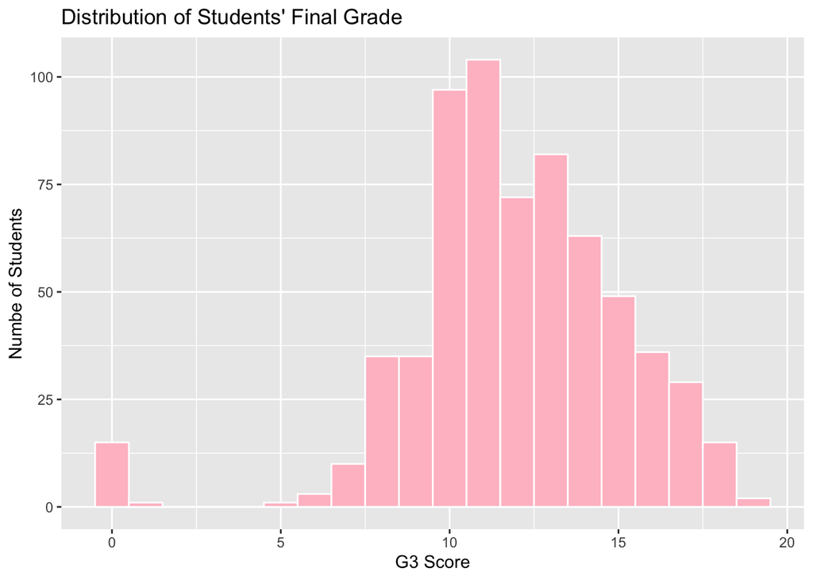

```r
#a histogram plot of overall G3 distribution
ggplot(student_fam, aes(x= G3))+
  geom_histogram(binwidth = 1, fill = "pink", color = "white")+
  labs(
    title = "Distribution of Students' Final Grade",
    x = "G3 Score",
    y = "Numbe of Students"
  )
```

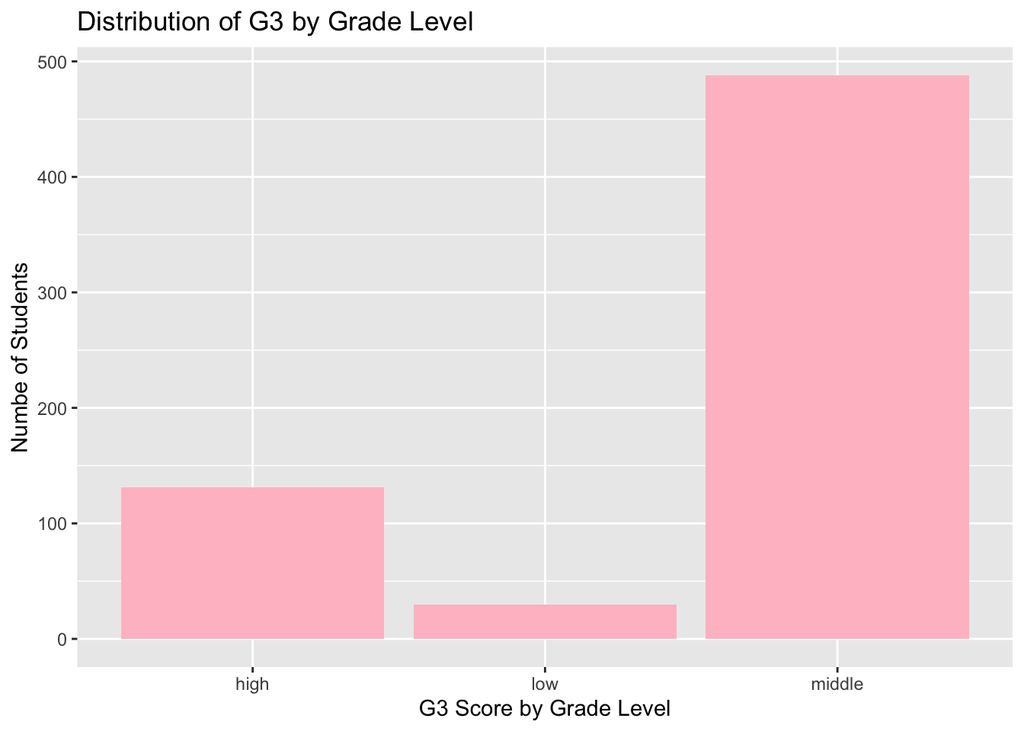

```r
#a bar chart plot to display the distribution of G3 in different levels
ggplot(student_fam, aes(x= grade_level))+
  geom_bar(fill = "pink")+
  labs(
    title = "Distribution of G3 by Grade Level",
    x = "G3 Score by Grade Level",
    y = "Numbe of Students"
  )
```

# Q3: Are there any difference in G3 between students with family support and students without family support?

```r
# compare the G3 between students with family support or and students without family support
student_famsup <- student_fam %>%
  group_by(famsup) %>% # group the students by family support variable
  summarize(
  mean_G3 = mean(G3, na.rm = TRUE),
  sd_G3 = sd(G3, na.rm = TRUE),
  n = n())

student_famsup
```

```
## # A tibble: 2 × 4
##   famsup mean_G3 sd_G3     n
##   <fct>    <dbl> <dbl> <int>
## 1 no        11.7  3.60   251
## 2 yes       12.1  2.97   398
```

```r
# famsup_no group(n=251), mean_G3=11.67(sd=3.60)
# famsup_yes group(n=398), mean_G3=12.07(sd=2.97)
```

# Q4: Using a plot to investigate whether students from larger family(GT3) differ in G3 scores compared to those from smaller families(LE3).

- According to the plot, we can see that the median scores for GT3 group(family size more than 3) and LE3 group(family size less than3) are very similar, this suggests that family size does not be strongly associated with students’ Portuguese reading performance. However, there is a litter more low-score outliers in GT3 group, this may indicate that students from larger families are likely to get lower scores in Portuguese reading performance.

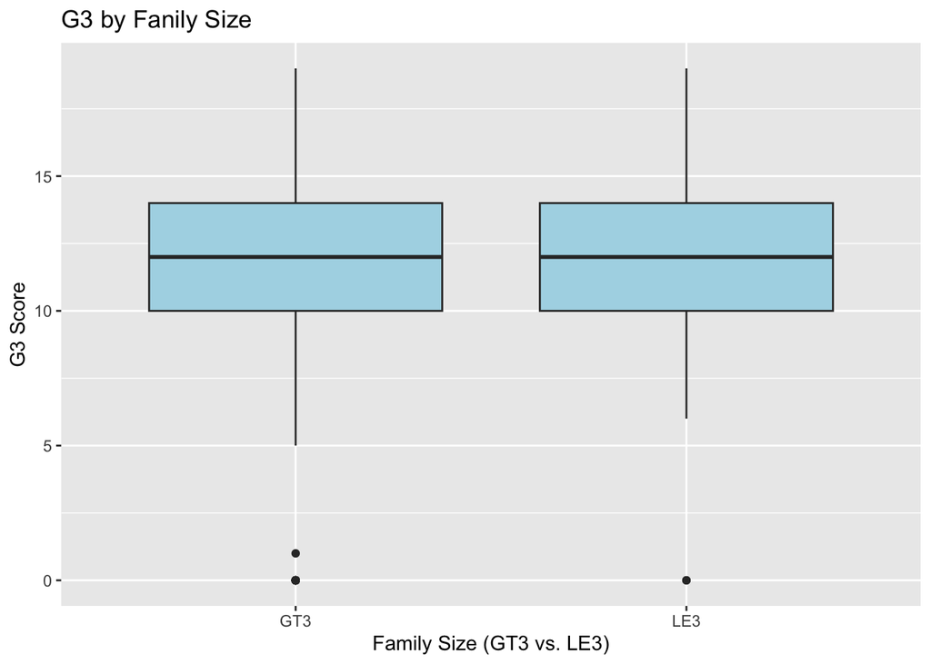

```r
ggplot(student_fam, aes(x = famsize, y = G3))+
  geom_boxplot(fill = "lightblue")+
  labs(
    title = "G3 by Fanily Size",
    x = "Family Size (GT3 vs. LE3)",
    y = "G3 Score"
  )
```

# Q5: How is the distribution of parents’ education levels among the 649 students?

```r
#count the number of students by mother's and father's education level
table(student_fam$Medu) # "0"-6; "1"-143; "2"-186,"3"-139; "4"-175
```

```
##
##   0   1   2   3   4
##   6 143 186 139 175
```

```r
table(student_fam$Fedu) # "0"-7; "1"-174; "2"-209,"3"-131; "4"-128
```

```
##
##   0   1   2   3   4
##   7 174 209 131 128
```

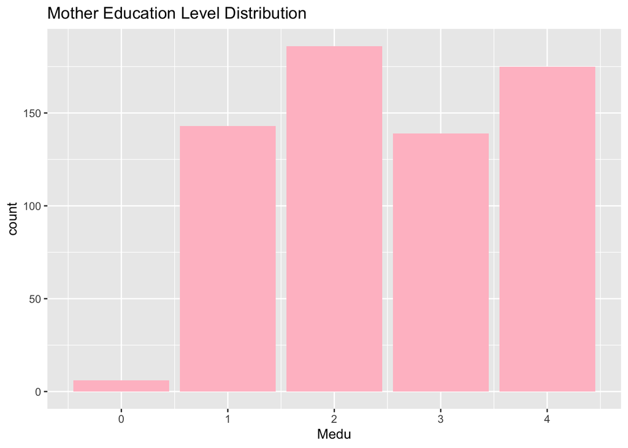

```r
# a plot for mother education level
ggplot(student_fam, aes(x = Medu))+
  geom_bar(fill = "pink")+
  labs(
    title = "Mother Education Level Distribution"
  )
```

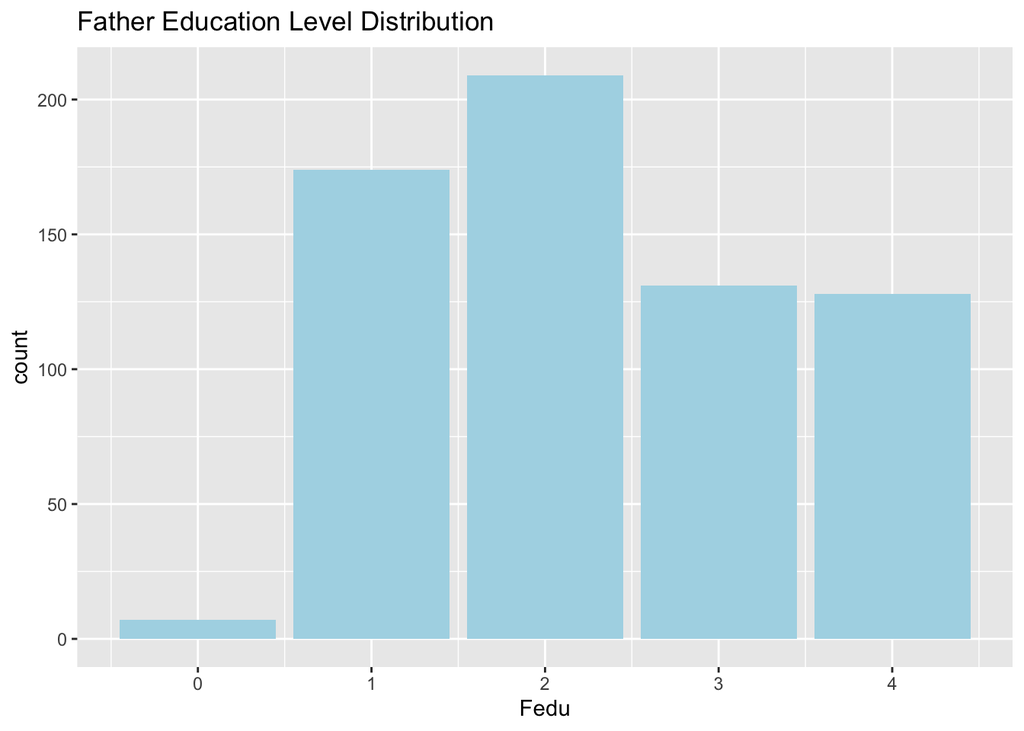

```r
# a plot for father education level
ggplot(student_fam, aes(x = Fedu))+
  geom_bar(fill = "lightblue")+
  labs(
    title = "Father Education Level Distribution"
  )
```

# Q6: Are there any difference in G3 for students with different parent education levels?

- Yes. From the plots, we can see some differences in G3 scores across different parent education levels.
- In general, students with higher parent education are likely to get higher G3 scores. Yet the differences are small.
- We can also see that the many students whose parents just had low education level, but the students can still get middle level of average G3 score. This suggests that parents education level may not totally predict student reading performance.

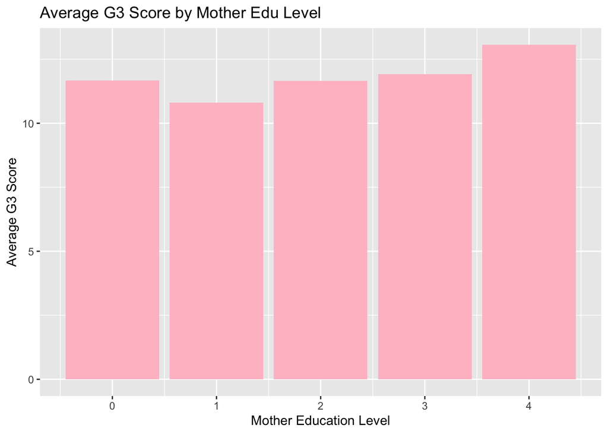

```r
# show the mean G3 grouped by mother education of different levels
medu_mean <- student_fam %>%
  group_by(Medu) %>%
  summarize(
    mean_G3 = mean(G3),
    n = n()
  )

# show the mean G3 grouped by father education of different levels
fedu_mean <- student_fam %>%
  group_by(Fedu) %>%
  summarize(
    mean_G3 = mean(G3),
    n = n()
  )

# visualize mother edu level and G3
ggplot(medu_mean, aes(x = Medu, y = mean_G3))+
  geom_bar(stat = "identity",fill = "pink")+ # show G3 mean score, not count student number
  labs(
    title = "Average G3 Score by Mother Edu Level",
    x = "Mother Education Level",
    y = "Average G3 Score"
  )
```

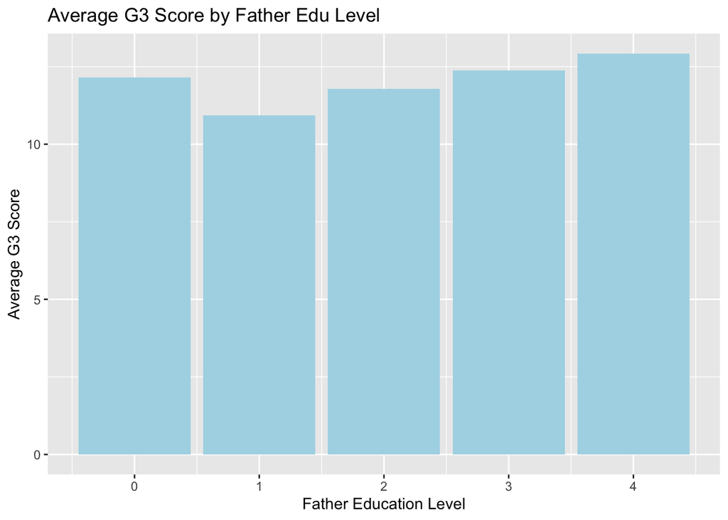

```r
# visualize father edu level and G3
ggplot(fedu_mean, aes(x = Fedu, y = mean_G3))+
  geom_bar(stat = "identity",fill = "lightblue")+ # show G3 mean score, not count student number
  labs(
    title = "Average G3 Score by Father Edu Level",
    x = "Father Education Level",
    y = "Average G3 Score"
  )
```

### Modeling

On the basis of the modeling results, we know that this model is statistically significant (F = 9.63, p<.001), but the explanatory power is relatively low (R-squared=0.07), indicating that the model can explain approximately 7% of the variance.

Among the predictors, only mother’s education level (Medu) shows a significant positive association with G3 (p<.001). The relationship among other family-related predictors and G3 are not significant.

This suggests that among all the selected family-related predictors, mother’s education level is the only one which is positively related to adolescents’ Portuguese reading performance.

```r
# modeling with 5 predictors
model1 <- lm(G3~famsize + Medu + Fedu + famsup + famrel,
             data = student_fam) # intercept= 9.0397

summary(model1)
```

```
##
## Call:
## lm(formula = G3 ~ famsize + Medu + Fedu + famsup + famrel, data = student_fam)
##
## Residuals:
##      Min       1Q   Median       3Q      Max
## -12.9104  -1.6210  -0.0111   1.9331   7.5262
##
## Coefficients:
##             Estimate Std. Error t value Pr(>|t|)
## (Intercept)   9.0397     0.6073  14.886  < 2e-16 ***
## famsizeLE3    0.3686     0.2694   1.368 0.171783
## Medu          0.4948     0.1423   3.477 0.000541 ***
## Fedu          0.2838     0.1471   1.929 0.054142 .
## famsupyes     0.1751     0.2549   0.687 0.492308
## famrel        0.1910     0.1286   1.485 0.137978
## ---
## Signif. codes:  0 '***' 0.001 '**' 0.01 '*' 0.05 '.' 0.1 ' ' 1
##
## Residual standard error: 3.128 on 643 degrees of freedom
## Multiple R-squared:  0.06969,    Adjusted R-squared:  0.06245
## F-statistic: 9.633 on 5 and 643 DF,  p-value: 7.001e-09
```

### Creating Function for Famrel

```r
famrel_level <- function(famrel) {
  if(famrel >= 3) {
    return("high")
  }else {
    return("low")
  }
}

famrel_level(4) # "high"
```

```
## [1] "high"
```

```r
famrel_level(2) # "low"
```

```
## [1] "low"
```

### Conclusion

The aim of this study is to explore to what extend family-related factors are associated with students’ Portuguese language performance. Based on UCI reading performance data, we found that mother’s education level is the only predictor that is significantly related to reading performance among 5 family-related predictors. This reflects the significance of women getting good education. We also need to acknowledge the limitation of the study, as the data was collected from just 2 middle schools in one country.